# Building Your Package

January 13, 2019

## Document Generation

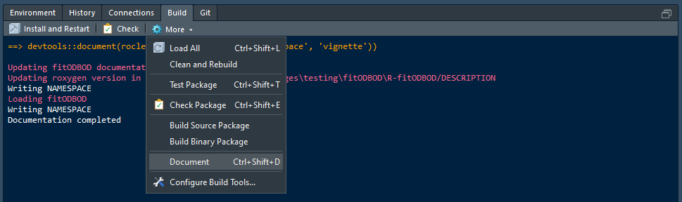

- If everything is in check build the documentation.
- This generates the Rd files for functions and data-sets.
- Build —> Document

## Clean and Rebuild

- After building the documentation now build the package again or for the first time.
- This is to update the changes you have done in the code or in data-sets.
- Build —> Clean and Rebuild

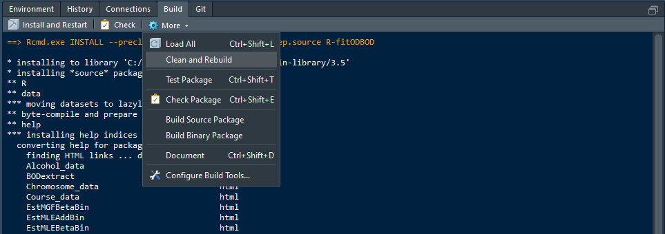

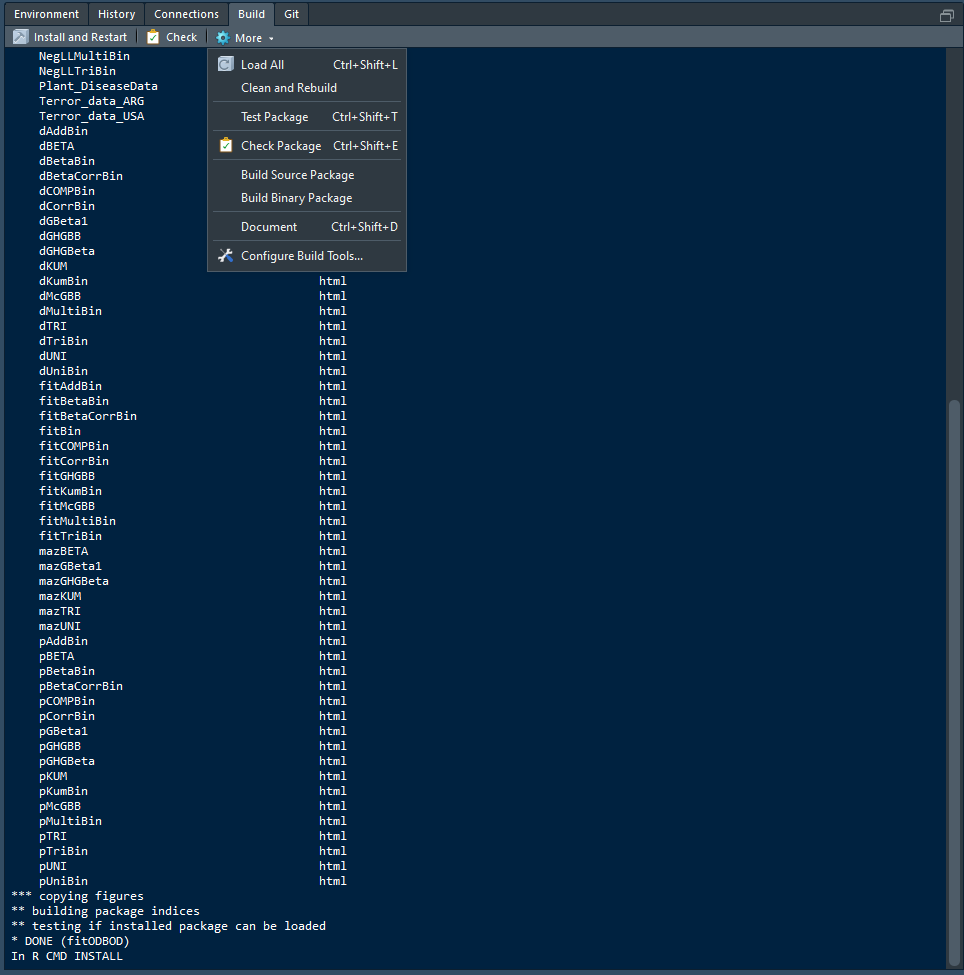

## Specll Check Rd files

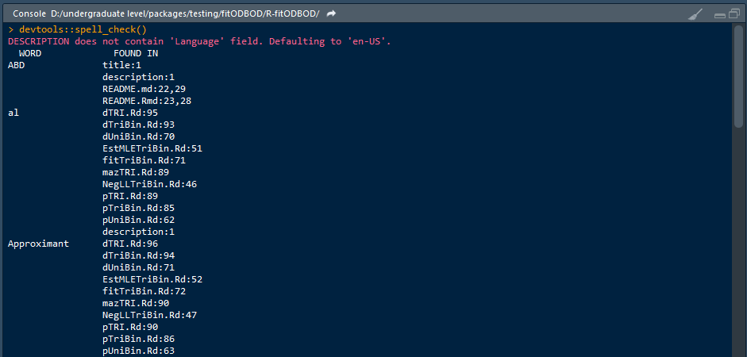

- In the R console use the below code and check for spelling errors in Rd files.
- > devtools::spell_check()

## Test the Package

- Run all the written tests on functions and data-sets.
- Build —> Test Package

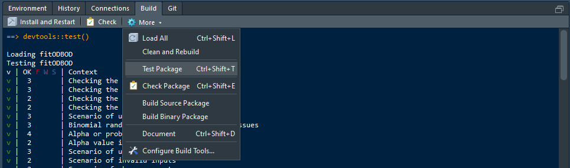

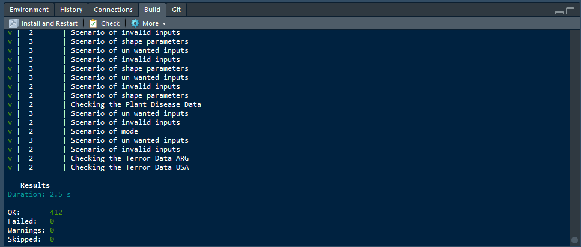

## Check for Errors

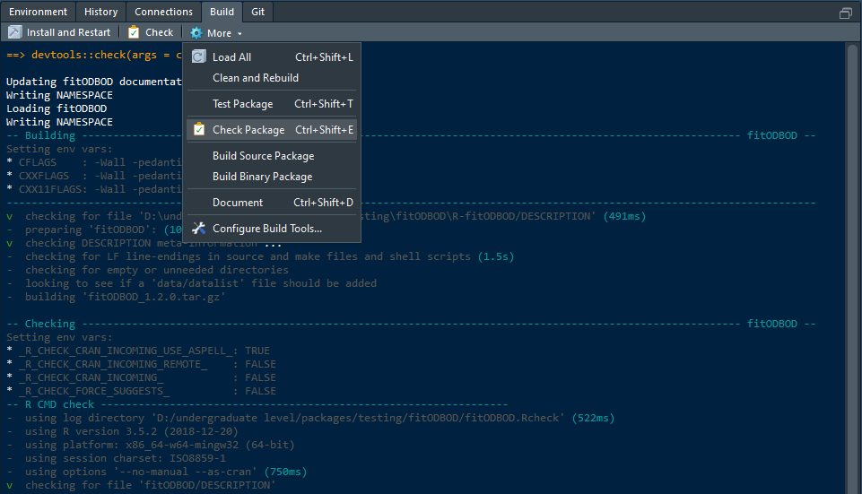

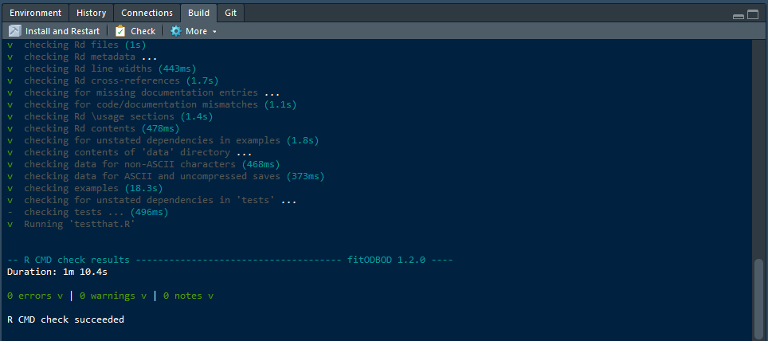

- Check for errors in package.
- Build —> Check Package
- Possibly if data-sets in proper form of extension.
- Unfinished code or Improper documentation.
- Missed packages or functions on Import.

## Build Source Package

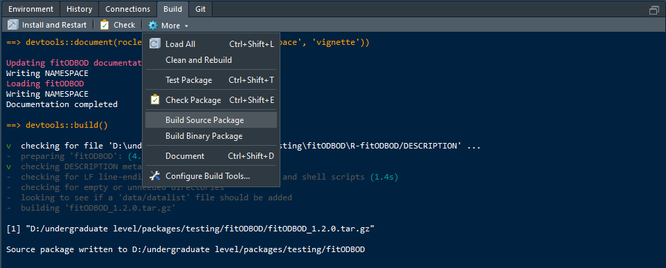

- If every thing in order then build package with tar.gz extension.
- Extension is for mac or Linux distributions.
- Build —> Build Source Package

## Build Binary Package

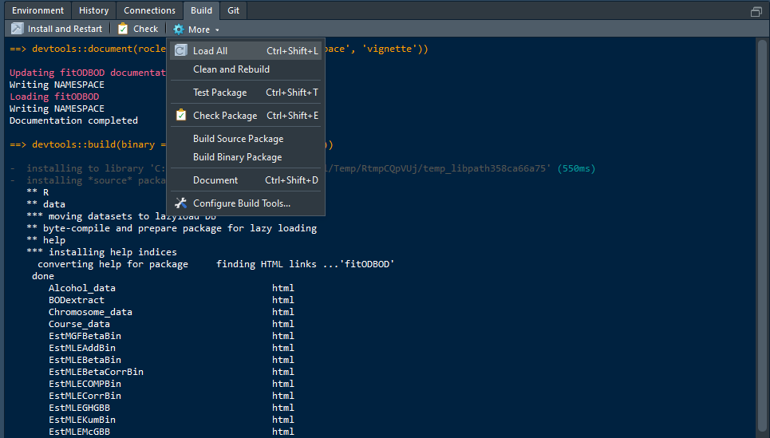

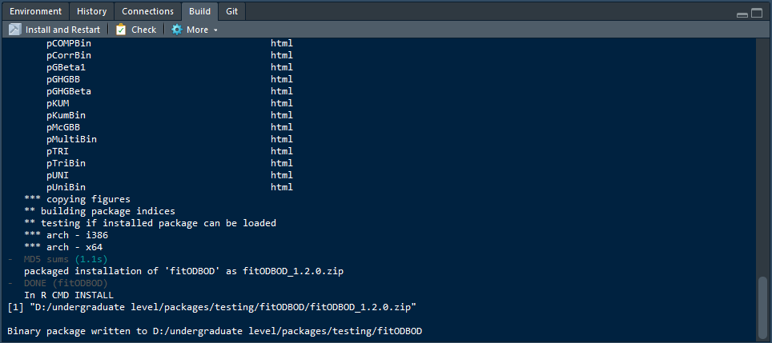

- Similarly build package with zip extension.
- This extension is for windows operating systems.
- Build —> Build Binary Package

*Configure Build Tools is for changing options related to package developement.*

## Generate Manual pdf

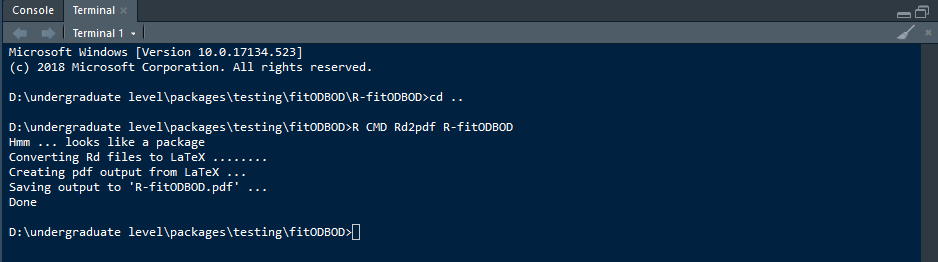

- Next to R console is the Terminal window.
- Type the below code to achieve a manual in pdf form compiled using the generated Rd files.
- This pdf document will be outside your project folder.

*cd ..* (to leave the project folder)

*R CMD Rd2pdf* (to generate the pdf file)

## Check Errors on Source Package

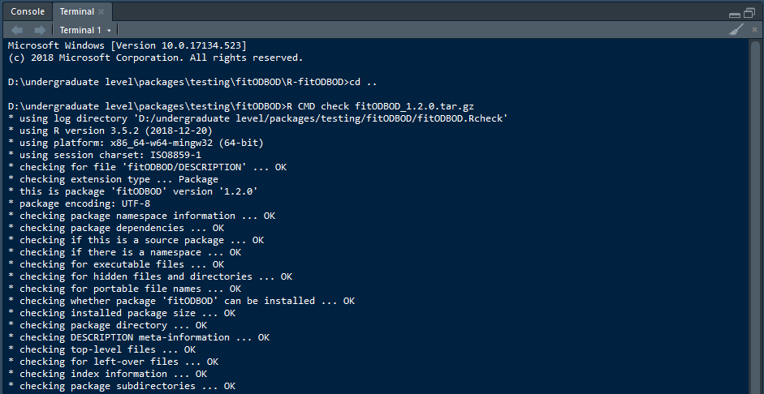

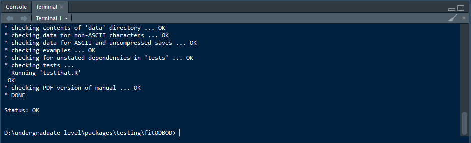

- Check for errors in the built source package.
- A log file will be outside the project folder after this process.
- This file will have information of the error checking process.

*cd ..* (to leave the project folder)

*R CMD check <package.name>.tar.gz* (check for errors and publish a log file)